# Appendix A. Analysis outputs for paper Development of Gaming Disorder: Underlying Risk Factors and Complex Temporal Dynamics

Marcel Martončik, Ivan Ropovik, Matúš Adamkovič

2023-12-24

# Descriptives

```
## $wave1
##                            [1]    [2]    [3]    [4]    [5]    [6]    [7]    [8]
## [1] igd9sf               1.000
## [2] gdt                  0.806      1
## [3] selfAssessment       0.608  0.623      1
## [4] adhd                 0.474  0.443  0.363      1
## [5] netAddiction         0.693  0.651  0.516  0.555      1
## [6] socMediaAddiction    0.480  0.402  0.359  0.375  0.506      1
## [7] impulsivity          0.313   0.31  0.282   0.45  0.349   0.21      1
## [8] stress               0.444  0.399  0.303  0.532  0.482  0.358  0.312      1
## [9] aggressionHostility  0.410  0.374  0.287  0.343   0.39  0.288  0.251  0.519
## [10] escape              0.548   0.43  0.308  0.285  0.408  0.354  0.177  0.474
## [11] socialSupport      -0.231 -0.203 -0.177 -0.196 -0.186 -0.091 -0.212 -0.422
## [12] anxiety             0.406  0.338  0.282  0.453  0.413  0.377  0.244  0.734
## [13] depression          0.421   0.37  0.295  0.471  0.435  0.329  0.288  0.742
```

[output cut: 143 more lines]

## Percentages of GD cases

```
## $igd9sf
## $igd9sf$`Above cut-off per waves`
## [1] 0.08460237 0.08460237 0.16920474
##
## $igd9sf$`Above cut-off in any wave`
## [1] 0.3384095
##
## $igd9sf$`Above cut-off in all waves`
## [1] 0
##
##
## $gdt
## $gdt$`Above cut-off per waves`
## [1] 2.791878 1.353638 1.269036
##
## $gdt$`Above cut-off in any wave`
## [1] 4.145516
##
## $gdt$`Above cut-off in all waves`
## [1] 0.2538071
##
##
## $selfassessment1
## $selfassessment1$`Above cut-off per waves`
## [1] 2.876481 2.622673 3.045685
##
## $selfassessment1$`Above cut-off in any wave`
## [1] 6.683587
##
## $selfassessment1$`Above cut-off in all waves`
## [1] 0.08460237
##
##
## $selfassessment2
## $selfassessment2$`Above cut-off per waves`
## [1] 1.353638 1.015228 0.676819
##
## $selfassessment2$`Above cut-off in any wave`
## [1] 2.453469
##
## $selfassessment2$`Above cut-off in all waves`
## [1] 0.1692047
```

# Reliability

```
##                      alpha.data1 alpha.data2 alpha.data3 omega.data1
## gdt                        0.919       0.924       0.934       0.919
## igd9sf                     0.918       0.928       0.933       0.920
## adhd                       0.819       0.828       0.839       0.826
## net_addiction              0.835       0.842       0.868       0.836
## soc_media_addiction        0.929       0.929       0.935       0.929
## impulsivity                0.868       0.870       0.882       0.872
## stress                     0.912       0.921       0.921       0.913
## aggression_hostility       0.843       0.846       0.855       0.844
## escape                     0.937       0.948       0.946       0.937
## social_support             0.912       0.920       0.923       0.913
## selfesteem                    NA          NA          NA          NA
## education                     NA          NA          NA          NA
##                      omega.data2 omega.data3
## gdt                        0.925       0.934
## igd9sf                     0.930       0.935
## adhd                       0.836       0.846
## net_addiction              0.843       0.868
## soc_media_addiction        0.929       0.935
## impulsivity                0.873       0.885
## stress                     0.922       0.922
## aggression_hostility       0.846       0.857
## escape                     0.948       0.947
## social_support             0.921       0.924
## selfesteem                    NA          NA
## education                     NA          NA
```

# Confirmatory factor analyses

```
##                variable  wave chisq.scaled df.scaled pvalue.scaled cfi.scaled
## 1                  adhd data1       56.096         9         0.000      0.967
## 2                  adhd data2       87.320         9         0.000      0.941
## 3                  adhd data3      103.088         9         0.000      0.929
## 4  aggression_hostility data1      403.325         9         0.000      0.662
## 5  aggression_hostility data2      325.112         9         0.000      0.672
## 6  aggression_hostility data3      401.893         9         0.000      0.598
## 7                escape data1        8.352         2         0.015      0.997
## 8                escape data2       12.845         2         0.002      0.994
## 9                escape data3       24.578         2         0.000      0.988
## 10                  gdt data1       10.741         2         0.005      0.991
## 11                  gdt data2        4.927         2         0.085      0.995
## 12                  gdt data3       16.024         2         0.000      0.978
## 13               igd9sf data1      164.517        27         0.000      0.935
## 14               igd9sf data2      146.083        27         0.000      0.927
```

[output cut: 47 more lines]

# Longitudinal changes

## Longitudinal interplay between gaming disorder and various predictors

Ignore the models throwing out an error.

**Brief explanation:**  
**i prefix** represents the intercept (sometimes also referred to as the initial status or level) of the growth factor. It captures the starting point or initial level of the variable.  
**s prefix** represents the slope (or rate of change) of the growth factor. It captures the rate of change over time for the variable.  
**iIgd_iPred:** regression of the intercept of IGD (the initial level of IGD) on the intercept of the predictor (iPredictor). Essentially, this path is asking whether the initial level of the predictor is associated with the initial level of IGD.  
**sIgd_iPred:** regression of the slope of IGD (the rate of change in IGD) on the intercept of the predictor (iPredictor). This path is asking whether the initial level of the predictoris associated with the rate of change in IGD over time.  
**sIgd_sPred:** regression of the slope of IGD on the slope of the predictor (sPredictor). It is asking whether the rate of change in the predictor is associated with the rate of change in Igd over time.  
All parameters accompanied by their associated p-values (raw and adjusted by Holm’s method).

```
## $igd9sf_Latent
##                       Variable  chiSq df pvalue   CFI   TLI RMSEA  SRMR
## 1                  adhd_Latent 57.363  8  0.000 0.981 0.964 0.072 0.016
## 2         net_addiction_Latent 54.109  8  0.000 0.985 0.972 0.070 0.016
## 3   soc_media_addiction_Latent 45.365  8  0.000 0.979 0.961 0.063 0.016
## 4           impulsivity_Latent 23.731  8  0.003 0.993 0.987 0.041 0.013
## 5                stress_Latent 24.139  8  0.002 0.994 0.990 0.041 0.011
## 6  aggression_hostility_Latent 25.701  8  0.001 0.992 0.985 0.043 0.013
## 7                escape_Latent 44.551  8  0.000 0.984 0.970 0.062 0.018
## 8        social_support_Latent  4.986  8  0.759 1.000 1.002 0.000 0.008
## 9               anxiety_Latent 26.434  8  0.001 0.992 0.985 0.044 0.012
## 10           depression_Latent 21.434  8  0.006 0.994 0.989 0.038 0.013
## 11       social_anxiety_Latent 21.078  8  0.007 0.994 0.989 0.037 0.014
## 12           selfesteem_Latent  6.336  8  0.610 1.000 1.001 0.000 0.007
## 13            education_Latent  1.484  8  0.993 1.000 1.005 0.000 0.005
```

[output cut: 116 more lines]

## Gaming disorder predicted by the predictors at baseline

```
## $igd9sf
##                       Variable chiSq df pvalue CFI   TLI RMSEA  SRMR iIgd_pred
## 1                  adhd_Latent 0.940  2  0.625   1 1.003 0.000 0.005     0.507
## 2         net_addiction_Latent 1.134  2  0.567   1 1.002 0.000 0.007     0.748
## 3   soc_media_addiction_Latent 0.856  2  0.652   1 1.003 0.000 0.005     0.508
## 4           impulsivity_Latent 1.921  2  0.383   1 1.000 0.000 0.007     0.318
## 5                stress_Latent 0.908  2  0.635   1 1.003 0.000 0.005     0.459
## 6  aggression_hostility_Latent 0.880  2  0.644   1 1.003 0.000 0.005     0.419
## 7                escape_Latent 0.377  2  0.828   1 1.004 0.000 0.003     0.532
## 8        social_support_Latent 0.255  2  0.880   1 1.005 0.000 0.002    -0.230
## 9               anxiety_Latent 1.363  2  0.506   1 1.002 0.000 0.006     0.420
## 10           depression_Latent 0.782  2  0.676   1 1.003 0.000 0.004     0.409
## 11       social_anxiety_Latent 2.160  2  0.340   1 1.000 0.008 0.007     0.373
## 12           selfesteem_Latent 0.337  2  0.845   1 1.005 0.000 0.003    -0.200
## 13            education_Latent 0.914  2  0.633   1 1.003 0.000 0.004    -0.016
```

[output cut: 74 more lines]

# Growth mixture model

## Results of GMMs

```
## $igd9sf
##      G    loglik npm      BIC   %class1  %class2  %class3  %class4
## gmm1 1 -3369.170   6 6781.225 100.00000       NA       NA       NA
## gmm2 2 -3111.578  10 6294.632  48.30842 51.69158       NA       NA
## gmm3 3 -3047.795  14 6195.657  24.78363 45.86939 29.34697       NA
## gmm4 4 -3045.145  18 6218.947  27.85208 11.80173 45.94807 14.39811
##
## $gdt
##      G    loglik npm      BIC    %class1  %class2  %class3 %class4
## gmm1 1 -3516.833   6 7076.584 100.000000       NA       NA      NA
## gmm2 2 -3260.235  10 6592.001  48.591549 51.40845       NA      NA
## gmm3 3 -3204.796  14 6509.736  43.740219 18.15336 38.10642      NA
## gmm4 4 -3196.063  18 6520.880   4.616588 19.09233 43.50548 32.7856
```

```
## $igd9sf
##   class1 class2 class3
## N 315.00 583.00 373.00
## %  24.78  45.87  29.35
##
## $gdt
##   class1 class2 class3
## N 559.00 232.00 487.00
## %  43.74  18.15  38.11
```

```
## $igd9sf
## intercept class1 intercept class2 intercept class1 intercept class2
##    -0.0006287056     0.4034752635     0.9790328781    -0.7553751514
## intercept class3      wave class1      wave class2      wave class3
##     0.1832314788     0.0338702283     0.0163255152    -0.0752135865
##       cholesky 1       cholesky 2       cholesky 3  varprop class 1
##     0.4441125335    -0.1391280195     0.1013667875     2.7525147907
##  varprop class 2           stderr
##    -0.0002822169     0.3791380378
##
## $gdt
## intercept class1 intercept class2 intercept class1 intercept class2
##     0.1372951947    -0.5088540037    -0.7422753540     1.2187972255
## intercept class3      wave class1      wave class2      wave class3
##     0.1394585942     0.0205180573    -0.0196109650    -0.0214509789
##       cholesky 1       cholesky 2       cholesky 3  varprop class 1
##     0.5831379230    -0.2101232126     0.1514258165     0.0000733388
##  varprop class 2           stderr
##     2.0006811403    -0.4001005662
```

```
## $igd9sf_LatentClass
## $igd9sf_LatentClass$testResults
## # A tibble: 7 × 6
##   statistic p.value variable    method      term             df
##       <dbl>   <dbl> <chr>       <chr>       <chr>         <dbl>
## 1    0.0468   0.977 gender      Chi-squared <NA>             NA
## 2    0.257    0.612 age         ANOVA       data[[class]]     1
## 3   NA       NA     age         ANOVA       Residuals      1145
## 4    0.196    0.658 gaming_time ANOVA       data[[class]]     1
## 5   NA       NA     gaming_time ANOVA       Residuals      1152
## 6    0.439    0.508 multiplayer ANOVA       data[[class]]     1
## 7   NA       NA     multiplayer ANOVA       Residuals      1128
##
## $igd9sf_LatentClass$describeDf
##         gender       age gaming_time multiplayer class
## mean 1.2429577 30.943463    3.929577    48.05694     1
## sd   0.4296268 10.292719    2.564084    36.83850     1
## mean 1.2410546 31.113636    3.973635    47.13462     2
## sd   0.4281267 10.047060    2.777820    36.41155     2
## mean 1.2359882 30.571429    4.023599    46.10030     3
## sd   0.4252425  8.963656    2.513756    36.34345     3
##
##
## $gdt_LatentClass
## $gdt_LatentClass$testResults
## # A tibble: 7 × 6
##   statistic p.value variable    method      term             df
##       <dbl>   <dbl> <chr>       <chr>       <chr>         <dbl>
## 1     1.04    0.593 gender      Chi-squared <NA>             NA
## 2     0.470   0.493 age         ANOVA       data[[class]]     1
## 3    NA      NA     age         ANOVA       Residuals      1151
## 4     0.633   0.426 gaming_time ANOVA       data[[class]]     1
## 5    NA      NA     gaming_time ANOVA       Residuals      1158
## 6     0.826   0.364 multiplayer ANOVA       data[[class]]     1
## 7    NA      NA     multiplayer ANOVA       Residuals      1134
##
## $gdt_LatentClass$describeDf
##         gender       age gaming_time multiplayer class
## mean 1.2372549 30.610672    4.050980    48.10956     1
## sd   0.4258175  9.671874    2.644145    36.20564     1
## mean 1.2153110 31.384615    3.985646    47.94660     2
## sd   0.4120248 10.608817    2.684497    37.59102     2
## mean 1.2517007 31.034169    3.913832    45.90421     3
## sd   0.4344830  9.543757    2.644345    36.19997     3
```

## Plot the trendlines for the distinct subgroups differing in their GD trajectory

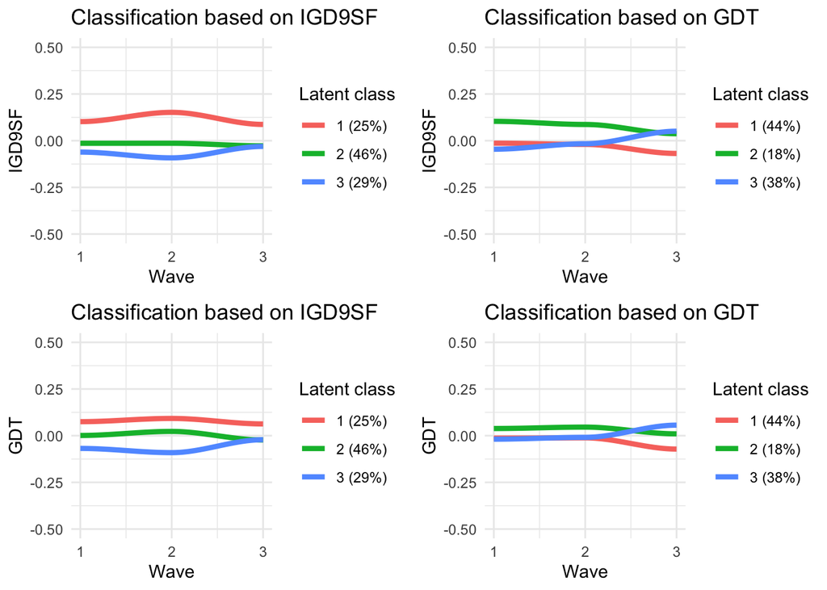

# Development of GD symptoms over time

## Summary tables for the lmer models

**Wave Coefficient:** the estimated fixed effect of wave on the symptom, indicating the average change in the symptom per unit increase in wave.  
**Standard Error:** the standard error of the wave coefficient, providing a measure of its uncertainty.  
**Intercept SD and Wave SD:** the standard deviations of the random intercepts and slopes, respectively, indicating the variability in these effects across participants.  
**Intercept-Wave Correlation:** the correlation between the random intercepts and slopes, indicating the extent to which participants with higher baseline symptom levels also tend to show larger wave effects.  
**LR Test p-value:** the p-value from the likelihood ratio test comparing the full model (including wave as a fixed effect and random slope) to the null model (excluding wave), providing evidence for whether wave has a significant effect on the symptom.

```
## $igd9sf
##      Symptom Wave Coefficient    SE Intercept SD Wave SD Residual SD
## 1 IGDS9-SF 1           -0.124 0.016        0.920   0.160       0.689
## 2 IGDS9-SF 2           -0.042 0.013        0.764   0.108       0.587
## 3 IGDS9-SF 3           -0.093 0.016        0.913   0.207       0.658
## 4 IGDS9-SF 4           -0.063 0.014        0.891   0.167       0.591
## 5 IGDS9-SF 5           -0.084 0.016        0.982   0.173       0.709
## 6 IGDS9-SF 6           -0.046 0.014        0.897   0.134       0.622
## 7 IGDS9-SF 7           -0.008 0.012        0.692   0.165       0.485
## 8 IGDS9-SF 8           -0.081 0.017        0.914   0.018       0.788
## 9 IGDS9-SF 9            0.008 0.011        0.695   0.157       0.465
##   Correlation p-value
## 1      -0.530   0.000
## 2      -0.347   0.002
## 3      -0.541   0.000
```

[output cut: 26 more lines]

```
## [1] -0.063
```

```
## [1] 5.676301
```

#### Plot

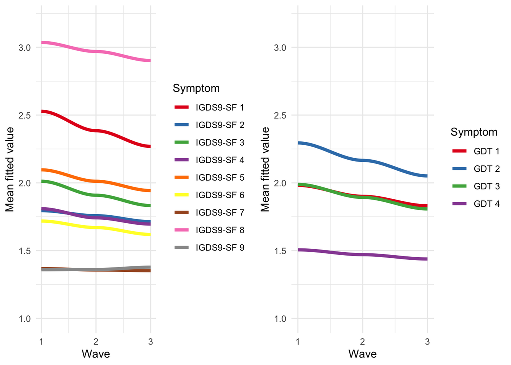

# Development of risk factors over time

```
## boundary (singular) fit: see help('isSingular')
```

[output not shown]

```
## boundary (singular) fit: see help('isSingular')
## boundary (singular) fit: see help('isSingular')
```

```
## refitting model(s) with ML (instead of REML)
## refitting model(s) with ML (instead of REML)
## refitting model(s) with ML (instead of REML)
```

```
## boundary (singular) fit: see help('isSingular')
## boundary (singular) fit: see help('isSingular')
```

```
## refitting model(s) with ML (instead of REML)
```

```
## boundary (singular) fit: see help('isSingular')
## boundary (singular) fit: see help('isSingular')
```

```
## refitting model(s) with ML (instead of REML)
```

```
## boundary (singular) fit: see help('isSingular')
## boundary (singular) fit: see help('isSingular')
```

```
## refitting model(s) with ML (instead of REML)
```

## Summary tables for the lmer models

```
##                       Predictor Wave Coefficient    SE Intercept SD Wave SD
## 1                 adhdMeanScore           -0.014 0.009        0.665   0.024
## 2         netAddictionMeanScore           -0.057 0.010        0.757   0.136
## 3    socMediaAddictionMeanScore           -0.044 0.011        0.786   0.101
## 4          impulsivityMeanScore           -0.006 0.005        0.481   0.049
## 5               stressMeanScore           -0.030 0.008        0.686   0.012
## 6  aggressionHostilityMeanScore           -0.005 0.014        1.066   0.183
## 7               escapeMeanScore           -0.032 0.015        0.965   0.001
## 8        socialSupportMeanScore            0.028 0.011        0.920   0.110
## 9              anxietyMeanScore           -0.022 0.011        0.806   0.063
## 10          depressionMeanScore           -0.030 0.011        0.739   0.028
## 11       socialAnxietyMeanScore           -0.022 0.014        0.951   0.025
## 12          selfesteemMeanScore            0.042 0.012        1.076   0.028
##    Residual SD Correlation p-value
## 1        0.394       0.944   0.106
## 2        0.420      -0.246   0.000
## 3        0.468      -0.498   0.000
## 4        0.226       0.103   0.264
## 5        0.351       1.000   0.000
## 6        0.583      -0.146   0.734
## 7        0.684       1.000   0.035
## 8        0.474      -0.190   0.013
## 9        0.507      -0.066   0.051
## 10       0.491       1.000   0.006
## 11       0.628       1.000   0.122
## 12       0.556       1.000   0.001
```

#### Plot

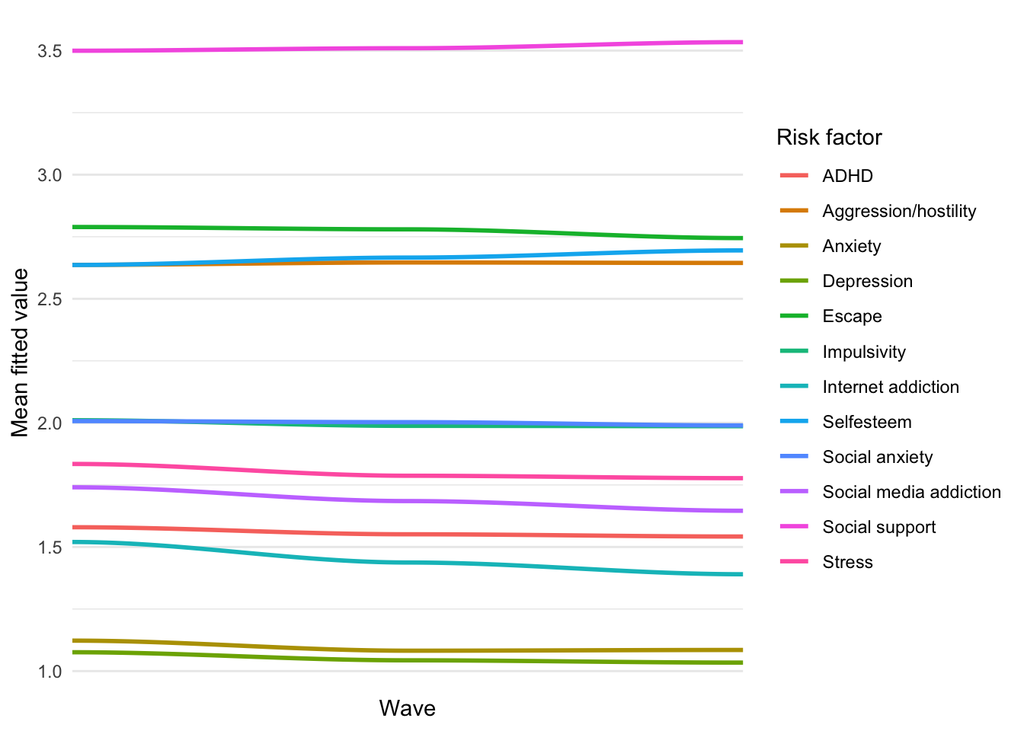

# Panel VAR network model

**For IGD9-SF and GDT, respectively.**

```
## Assuming denominator n was used in covariance computation (covtype = 'ML').
```

[output not shown]

```
##            Measure     Value
##               logl -34393.14
##  unrestricted.logl -34089.13
##      baseline.logl -44675.65
##               nvar        27
##               nobs       405
##               npar       180
##                 df       225
##          objective      8.57
##              chisq    608.01
##             pvalue       ~ 0
##     baseline.chisq  21173.04
##        baseline.df       378
##    baseline.pvalue       ~ 0
##                nfi      0.97
##               pnfi      0.58
##                tli      0.97
##               nnfi      0.97
##                rfi      0.95
##                ifi      0.98
##                rni      0.98
##                cfi      0.98
##              rmsea     0.038
##     rmsea.ci.lower     0.034
##     rmsea.ci.upper     0.042
##       rmsea.pvalue       1.0
##             aic.ll  69146.27
##            aic.ll2  69211.37
##              aic.x    158.01
##             aic.x2    968.01
##                bic  70059.77
##               bic2  69488.02
##            ebic.25  70653.02
##             ebic.5  71246.27
##            ebic.75  71720.87
##              ebic1  72432.77
##            Measure     Value
##               logl -34565.80
##  unrestricted.logl -34089.13
##      baseline.logl -44675.65
```

[output cut: 425 more lines]

```
##  Eta_7 -- Eta_2 0.23 0.052 < 0.0001   7   2  83
##  Eta_9 -- Eta_5 0.22 0.068   0.0013   9   5  84
##  Eta_9 -- Eta_7 0.24 0.059 < 0.0001   9   7  85
##
##  -  delta_zeta_between (diagonal)
##   var1  op  var2  est       se        p row col par
##  Eta_1 ~/~ Eta_1 0.49    0.017 < 0.0001   1   1  86
##  Eta_2 ~/~ Eta_2 0.27    0.014 < 0.0001   2   2  87
##  Eta_3 ~/~ Eta_3 0.21    0.044 < 0.0001   3   3  88
##  Eta_4 ~/~ Eta_4  ~ 0 < 0.0001        1   4   4  89
##  Eta_5 ~/~ Eta_5 0.40    0.030 < 0.0001   5   5  90
##  Eta_6 ~/~ Eta_6 0.19    0.040 < 0.0001   6   6  91
##  Eta_7 ~/~ Eta_7 0.35    0.012 < 0.0001   7   7  92
##  Eta_8 ~/~ Eta_8 0.75    0.021 < 0.0001   8   8  93
##  Eta_9 ~/~ Eta_9 0.31    0.027 < 0.0001   9   9  94
```

```
## Assuming denominator n-1 was used in covariance computation (covtype = 'UB').
```

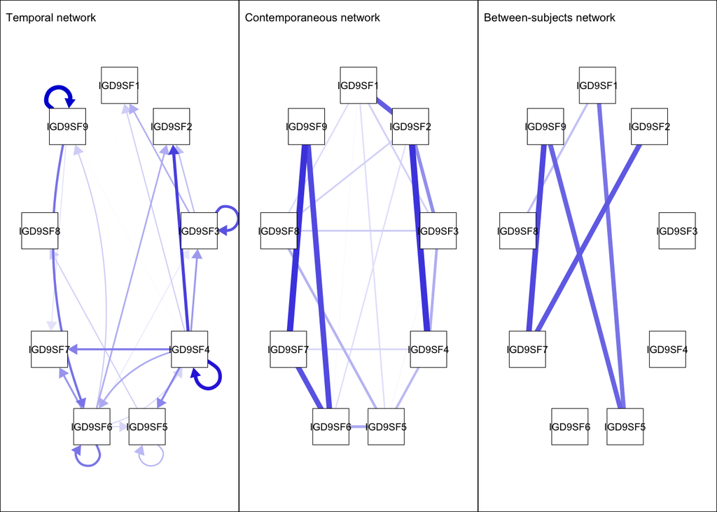

```
##            Measure     Value
##               logl -15051.57
##  unrestricted.logl -14982.34
##      baseline.logl -20250.35
##               nvar        12
##               nobs        90
##               npar        40
##                 df        50
##          objective      3.41
##              chisq    138.45
##             pvalue       ~ 0
##     baseline.chisq  10536.01
##        baseline.df        78
##    baseline.pvalue       ~ 0
##                nfi      0.99
##               pnfi      0.63
##                tli      0.99
##               nnfi      0.99
##                rfi      0.98
##                ifi      0.99
##                rni      0.99
##                cfi      0.99
##              rmsea     0.039
##     rmsea.ci.lower     0.031
##     rmsea.ci.upper     0.046
##       rmsea.pvalue      0.99
##             aic.ll  30183.13
##            aic.ll2  30186.01
##              aic.x     38.45
##             aic.x2    218.45
##                bic  30386.13
##               bic2  30259.07
##            ebic.25  30485.53
##             ebic.5  30584.92
##            ebic.75  30664.44
##              ebic1  30783.71
##            Measure     Value
##               logl -15071.53
##  unrestricted.logl -14982.34
##      baseline.logl -20250.35
```

[output cut: 205 more lines]

```
##  Eta_2 <- Eta_4 0.066 0.033    0.048   2   4  16
##
##  -  omega_zeta_between (symmetric)
##   var1 op  var2  est    se        p row col par
##  Eta_2 -- Eta_1 0.57 0.037 < 0.0001   2   1  17
##  Eta_3 -- Eta_1 0.61 0.038 < 0.0001   3   1  18
##  Eta_4 -- Eta_2 0.12 0.044   0.0057   4   2  19
##  Eta_4 -- Eta_3 0.51 0.034 < 0.0001   4   3  20
##
##  -  delta_zeta_between (diagonal)
##   var1  op  var2  est    se        p row col par
##  Eta_1 ~/~ Eta_1 0.24 0.015 < 0.0001   1   1  21
##  Eta_2 ~/~ Eta_2 0.39 0.018 < 0.0001   2   2  22
##  Eta_3 ~/~ Eta_3 0.30 0.017 < 0.0001   3   3  23
##  Eta_4 ~/~ Eta_4 0.33 0.013 < 0.0001   4   4  24
```

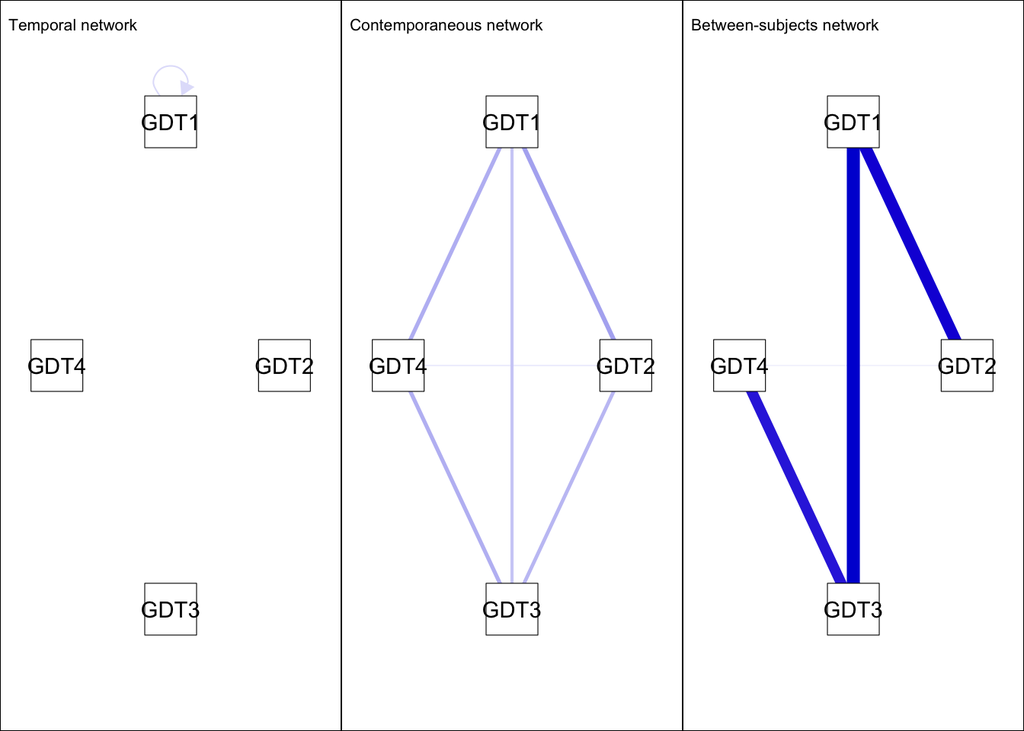